# [SIVOCS] Factor Analyis and Model Design

5/22/2021

# 1. Variable Elimination

1.1. Previously removed variables

```r
features_to_rm <- tail(feature_list$X0, 40)
# Qualitatively select the worse performing features
features_to_rm <- features_to_rm[c(22,26,29:40)]
features_to_rm <- c(features_to_rm,
                    "dissChannels.trad.",
                    "dissChannels.socmed.",
                    "dissChannels.consult.",
                    "dissChannels.events.",
                    "dissChannels.public.",
                    "concepts.data.",
                    "concepts.code.",
                    "concepts.infra.",
                    "contribToSI.rate.",
                    "groupsInvolved.res.",
                    "natureOfInvolvement.res.",
                    "contribToSI.rate.",
                    "concepts2"
                    )

# remove the weak features
df_red <- feat_df.num_o[, !(colnames(feat_df.num_o ) %in% features_to_rm)]
```

1.2. We got a number of variables which actually measures the researchers, remove those.

- Remove the variables from the previous 1. factor
- Remove bussiness variables -> useless
- Remove scalability (measuring something else)

```r
## SI Familiarity Factor
factor_1 <- c("familiarWithSI.response.", "transdisciplinaryExp.rate.")
df_red <- df_red %>%
 dplyr::select(-all_of(factor_1))

## MISC:business
factor_busi <- c("groupsInvolved.busi.", "impactTargetGroup.busi.", "kindOfChange.busi.")
df_red <- df_red %>%
  dplyr::select(-all_of(factor_busi))


## MISC:scalability
factor_scale <- c("scalabilityRating.up.", "scalabilityRating.out.", "scalabilityRating.deep.")
df_red <- df_red %>%
  dplyr::select(-all_of(factor_scale))

colnames(df_red)
```

```
##  [1] "motivation.pheno."               "motivation.prob."
##  [3] "motivation.welfare."             "benefitForNonAcademy"
##  [5] "impulseForNonAcad.soc."          "impulseForNonAcad.econ."
##  [7] "impulseForNonAcad.ecol."         "impulseForNonAcad.health."
##  [9] "impulseForNonAcad.tech."         "groupsInvolved.civsoc."
## [11] "groupsInvolved.policy."          "groupsInvolved.citiz."
## [13] "groupsInvolved.media."           "groupsInvolved.welfare."
## [15] "natureOfInvolvement.civsoc."     "natureOfInvolvement.policy."
## [17] "natureOfInvolvement.citiz."      "natureOfInvolvement.media."
## [19] "natureOfInvolvement.welfare."    "targetGroupsGoals.socneeds."
## [21] "targetGroupsGoals.socgroups."    "targetGroupsGoals.improve."
## [23] "targetGroupsGoals.empower."      "targetGroupsGoals.diversity."
## [25] "impactTargetGroup.pub."          "impactTargetGroup.socgr."
## [27] "impactTargetGroup.welfare."      "impactTargetGroup.civsoc."
## [29] "impactTargetGroup.policy."       "impactTargetGroup.acad."
## [31] "kindOfChange.pub."               "kindOfChange.socgr."
## [33] "kindOfChange.welfare."           "kindOfChange.civsoc."
## [35] "kindOfChange.policy."            "kindOfChange.acad."
## [37] "adoptByPolicyHow.SQ001."         "Impactstatements.capab."
## [39] "Impactstatements.emanc."         "Impactstatements.understanding."
## [41] "Impactstatements.mitig."         "Impactstatements.unknown."
## [43] "Impactstatements.unaddressed."
```

- Generate a df without the variables including another dimension of observation (researchers instead of projects) to run the FA on

```r
df_model <- feat_df.num_o %>%
  dplyr::select(-all_of(c(factor_1, "contribToSI.rate.")))

colnames(df_model)
```

```
##  [1] "motivation.pheno."               "motivation.prob."
##  [3] "motivation.welfare."             "benefitForNonAcademy"
##  [5] "impulseForNonAcad.soc."          "impulseForNonAcad.econ."
##  [7] "impulseForNonAcad.ecol."         "impulseForNonAcad.health."
##  [9] "impulseForNonAcad.tech."         "groupsInvolved.res."
## [11] "groupsInvolved.busi."            "groupsInvolved.civsoc."
## [13] "groupsInvolved.policy."          "groupsInvolved.citiz."
## [15] "groupsInvolved.media."           "groupsInvolved.welfare."
## [17] "natureOfInvolvement.res."        "natureOfInvolvement.busi."
## [19] "natureOfInvolvement.civsoc."     "natureOfInvolvement.policy."
## [21] "natureOfInvolvement.citiz."      "natureOfInvolvement.media."
## [23] "natureOfInvolvement.welfare."    "targetGroupsGoals.socneeds."
## [25] "targetGroupsGoals.socgroups."    "targetGroupsGoals.improve."
## [27] "targetGroupsGoals.empower."      "targetGroupsGoals.diversity."
## [29] "concepts.pub."                   "concepts.data."
```

[output cut: 22 more lines]

# 2. Factor Analysis

## 2.1. Scree Plot

Determine Number of Factors to Extract

```r
library(nFactors)
```

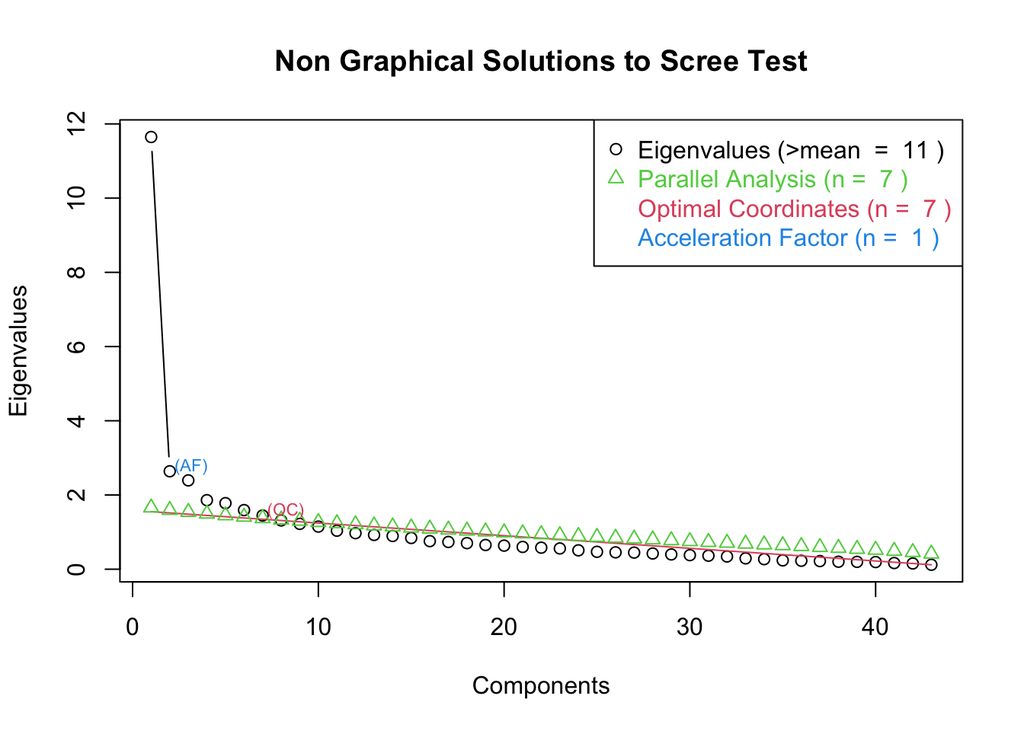

```r
ev <- eigen(cor(df_red)) # get eigenvalues

ap <- parallel(subject=nrow(df_red),var=ncol(df_red),
               rep=1000,cent=.05)
nS <- nScree(x=ev$values, aparallel=ap$eigen$qevpea)
plotnScree(nS)  # 9 Factors
```

The optimal number of factors is 7 (as opposed to 8 in the previous one)

## 2.2. Exploratory Factor Analysis

```r
# --- FA explanatory
# Maximum Likelihood Factor Analysis
# entering raw data and extracting 8 factors,
# with varimax rotation
fit <- factanal(df_red, 7, rotation="varimax")
print(fit, digits=2, cutoff=.3, sort=TRUE)
```

```
##
## Call:
## factanal(x = df_red, factors = 7, rotation = "varimax")
##
## Uniquenesses:
##               motivation.pheno.                motivation.prob.
##                            0.94                            0.93
##             motivation.welfare.            benefitForNonAcademy
##                            0.41                            0.30
##          impulseForNonAcad.soc.         impulseForNonAcad.econ.
##                            0.63                            0.84
##         impulseForNonAcad.ecol.       impulseForNonAcad.health.
##                            0.82                            0.70
##         impulseForNonAcad.tech.          groupsInvolved.civsoc.
##                            0.95                            0.25
##          groupsInvolved.policy.           groupsInvolved.citiz.
##                            0.18                            0.48
##           groupsInvolved.media.         groupsInvolved.welfare.
##                            0.81                            0.21
##     natureOfInvolvement.civsoc.     natureOfInvolvement.policy.
##                            0.38                            0.60
##      natureOfInvolvement.citiz.      natureOfInvolvement.media.
##                            0.54                            0.91
##    natureOfInvolvement.welfare.     targetGroupsGoals.socneeds.
##                            0.36                            0.49
##    targetGroupsGoals.socgroups.      targetGroupsGoals.improve.
##                            0.55                            0.38
##      targetGroupsGoals.empower.    targetGroupsGoals.diversity.
##                            0.50                            0.64
##          impactTargetGroup.pub.        impactTargetGroup.socgr.
##                            0.37                            0.43
##      impactTargetGroup.welfare.       impactTargetGroup.civsoc.
##                            0.51                            0.27
##       impactTargetGroup.policy.         impactTargetGroup.acad.
##                            0.26                            0.73
##               kindOfChange.pub.             kindOfChange.socgr.
##                            0.65                            0.50
##           kindOfChange.welfare.            kindOfChange.civsoc.
##                            0.59                            0.38
##            kindOfChange.policy.              kindOfChange.acad.
```

[output cut: 93 more lines]

```
## adoptByPolicyHow.SQ001.
## Impactstatements.capab.
## Impactstatements.understanding.
## Impactstatements.mitig.
## Impactstatements.unknown.
## Impactstatements.unaddressed.    0.37
##
##                Factor1 Factor2 Factor3 Factor4 Factor5 Factor6 Factor7
## SS loadings       4.78    3.23    2.79    2.53    2.29    2.27    1.47
## Proportion Var    0.11    0.08    0.06    0.06    0.05    0.05    0.03
## Cumulative Var    0.11    0.19    0.25    0.31    0.36    0.42    0.45
##
## Test of the hypothesis that 7 factors are sufficient.
## The chi square statistic is 1861.85 on 623 degrees of freedom.
## The p-value is 1.4e-123
```

```r
model_theory <-"
  ## intention_agency
  ia_human_condition =~ motivation.welfare.+benefitForNonAcademy+impulseForNonAcad.soc.+targetGroupsGoals.improve.+impulseForNonAcad.health.+impulseForNonAcad.ecol.+kindOfChange.pub.+kindOfChange.socgr.+kindOfChange.welfare.+kindOfChange.civsoc.

  ia_non_academic =~ impulseForNonAcad.econ.+impulseForNonAcad.tech.

  ## transdisciplinary_apects
  transdisciplinary_social =~ groupsInvolved.citiz.+groupsInvolved.civsoc.+groupsInvolved.welfare.+natureOfInvolvement.citiz.+natureOfInvolvement.civsoc.+natureOfInvolvement.welfare.+targetGroupsGoals.socneeds.+targetGroupsGoals.socgroups.+targetGroupsGoals.empower.+targetGroupsGoals.diversity.
  outcome =~ impactTargetGroup.pub.+impactTargetGroup.socgr.+impactTargetGroup.welfare.+impactTargetGroup.civsoc.+Impactstatements.capab.+Impactstatements.emanc.+Impactstatements.understanding.+Impactstatements.mitig.+Impactstatements.unknown.+Impactstatements.unaddressed.

  ## MISC:policy
  policy =~ groupsInvolved.policy.+impactTargetGroup.policy.+kindOfChange.policy.+natureOfInvolvement.policy.+groupsInvolved.policy.+adoptByPolicyHow.SQ001."
```

```r
model_theory2 <-"
  # SOLUTION ORIENTATION
  ia_human_condition =~
  motivation.welfare. +
  benefitForNonAcademy +
  impulseForNonAcad.soc. +
  targetGroupsGoals.improve.

  ia_nonacad_impulse =~
  impulseForNonAcad.econ. +
  impulseForNonAcad.tech. +
  impulseForNonAcad.health. +
  impulseForNonAcad.ecol.


  #  ACTORS & NETWORKS
  transdisciplinary_involvement =~
  groupsInvolved.citiz. +
  groupsInvolved.civsoc. +
  groupsInvolved.welfare. +
  natureOfInvolvement.citiz. +
  natureOfInvolvement.civsoc. +
  natureOfInvolvement.welfare.


  transdisciplinary_goals =~
  targetGroupsGoals.socneeds. +
  targetGroupsGoals.socgroups. +
  targetGroupsGoals.empower. +
  targetGroupsGoals.diversity.

  # NOVELTY
  innovativeness =~
  kindOfChange.pub. +
  kindOfChange.socgr. +
  kindOfChange.welfare. +
  kindOfChange.civsoc.


  # OUTCOME
  outcomes =~
  impactTargetGroup.pub. +
  impactTargetGroup.socgr. +
  impactTargetGroup.welfare. +
  impactTargetGroup.civsoc. +
  Impactstatements.capab. +
  Impactstatements.emanc. +
  Impactstatements.understanding. +
  Impactstatements.mitig. +
  Impactstatements.unknown. +
  Impactstatements.unaddressed.

  # MISC:policy
  policy =~ groupsInvolved.policy.+impactTargetGroup.policy.+kindOfChange.policy.+natureOfInvolvement.policy.+groupsInvolved.policy.+adoptByPolicyHow.SQ001."
```

```r
model_theory3 <-"
  # SOLUTION ORIENTATION
  ia_human_condition =~
  motivation.welfare. +
  benefitForNonAcademy +
  impulseForNonAcad.soc. +
  targetGroupsGoals.improve.

  ia_nonacad_impulse =~
  impulseForNonAcad.econ. +
  impulseForNonAcad.tech. +
  impulseForNonAcad.health. +
  impulseForNonAcad.ecol.


  #  ACTORS & NETWORKS
  transdisciplinary_involvement =~
  groupsInvolved.citiz. +
  groupsInvolved.civsoc. +
  groupsInvolved.welfare. +
  groupsInvolved.policy. +
  natureOfInvolvement.citiz. +
  natureOfInvolvement.civsoc. +
  natureOfInvolvement.welfare. +
  natureOfInvolvement.policy.


  transdisciplinary_goals =~
  targetGroupsGoals.socneeds. +
  targetGroupsGoals.socgroups. +
  targetGroupsGoals.empower. +
  targetGroupsGoals.diversity.

  # NOVELTY
  innovativeness =~
  kindOfChange.pub. +
  kindOfChange.socgr. +
  kindOfChange.welfare. +
  kindOfChange.civsoc. +
  kindOfChange.policy.


  # OUTCOME
  outcome =~
  impactTargetGroup.pub. +
  impactTargetGroup.socgr. +
  impactTargetGroup.welfare. +
  impactTargetGroup.civsoc. +
  impactTargetGroup.policy. +
  Impactstatements.capab. +
  Impactstatements.emanc. +
  Impactstatements.understanding. +
  Impactstatements.mitig. +
  Impactstatements.unknown. +
  Impactstatements.unaddressed. +
  adoptByPolicyHow.SQ001.
"
```

### 2.3.1. Conf. Factor analysis: Model 1

```r
fit_theory <- cfa(model_theory, df_model)
summary(fit_theory, fit.measures = T, standardized = T)
```

```
## lavaan 0.6-11 ended normally after 133 iterations
##
##   Estimator                                         ML
##   Optimization method                           NLMINB
##   Number of model parameters                        84
##
##   Number of observations                           361
##
## Model Test User Model:
##
##   Test statistic                              3099.919
##   Degrees of freedom                               619
##   P-value (Chi-square)                           0.000
##
## Model Test Baseline Model:
##
##   Test statistic                              7255.672
##   Degrees of freedom                               666
##   P-value                                        0.000
##
## User Model versus Baseline Model:
##
##   Comparative Fit Index (CFI)                    0.624
##   Tucker-Lewis Index (TLI)                       0.595
##
## Loglikelihood and Information Criteria:
##
##   Loglikelihood user model (H0)             -15631.644
##   Loglikelihood unrestricted model (H1)     -14081.684
##
##   Akaike (AIC)                               31431.288
##   Bayesian (BIC)                             31757.954
##   Sample-size adjusted Bayesian (BIC)        31491.461
##
## Root Mean Square Error of Approximation:
##
##   RMSEA                                          0.105
##   90 Percent confidence interval - lower         0.102
##   90 Percent confidence interval - upper         0.109
##   P-value RMSEA <= 0.05                          0.000
```

[output cut: 160 more lines]

```
##    .Impctsttmnts..    2.819    0.237   11.918    0.000    2.819    0.436
##    .Impctsttmnts..    6.491    0.525   12.356    0.000    6.491    0.519
##    .Impctsttmnts..    2.890    0.237   12.212    0.000    2.890    0.488
##    .Impctsttmnts..    8.790    0.683   12.870    0.000    8.790    0.672
##    .Impctsttmnts..   12.137    0.917   13.242    0.000   12.137    0.856
##    .grpsInvlvd.pl.    0.186    0.017   11.201    0.000    0.186    0.467
##    .impctTrgtGrp..    2.147    0.311    6.906    0.000    2.147    0.226
##    .kndOfChng.plc.    0.411    0.036   11.379    0.000    0.411    0.487
##    .ntrOfInvlvmn..    0.472    0.037   12.897    0.000    0.472    0.776
##    .adptBPH.SQ001.    0.063    0.005   12.964    0.000    0.063    0.797
##     ia_human_cndtn    5.903    0.802    7.361    0.000    1.000    1.000
##     ia_non_academc    0.006    0.018    0.320    0.749    1.000    1.000
##     trnsdscplnry_s    0.187    0.027    6.903    0.000    1.000    1.000
##     outcome           3.322    0.563    5.899    0.000    1.000    1.000
##     policy            0.213    0.028    7.640    0.000    1.000    1.000
```

```r
modificationindices(fit_theory) %>%
  arrange(-mi) %>%
  head(10)
```

```
##                        lhs op                             rhs      mi   epc
## 1   groupsInvolved.civsoc. ~~     natureOfInvolvement.civsoc. 143.600 0.099
## 2  groupsInvolved.welfare. ~~    natureOfInvolvement.welfare. 131.886 0.153
## 3     kindOfChange.civsoc. ~~       impactTargetGroup.civsoc. 118.938 0.580
## 4    kindOfChange.welfare. ~~      impactTargetGroup.welfare.  83.118 0.738
## 5   groupsInvolved.policy. ~~     natureOfInvolvement.policy.  75.238 0.154
## 6    groupsInvolved.citiz. ~~      natureOfInvolvement.citiz.  75.128 0.111
## 7      kindOfChange.socgr. ~~        impactTargetGroup.socgr.  72.719 0.552
## 8   groupsInvolved.civsoc. ~~       impactTargetGroup.civsoc.  62.158 0.309
## 9   impulseForNonAcad.soc. ~~ Impactstatements.understanding.  60.528 0.434
## 10    benefitForNonAcademy ~~      targetGroupsGoals.improve.  60.110 0.098
##    sepc.lv sepc.all sepc.nox
## 1    0.099    0.660    0.660
## 2    0.153    0.645    0.645
## 3    0.580    0.596    0.596
## 4    0.738    0.501    0.501
## 5    0.154    0.518    0.518
## 6    0.111    0.496    0.496
## 7    0.552    0.477    0.477
## 8    0.309    0.437    0.437
## 9    0.434    0.433    0.433
## 10   0.098    0.564    0.564
```

### 2.3.2. Conf. Factor analysis: Model 2

```r
fit_theory2 <- cfa(model_theory2, df_model)
# Scale using latent variable variance rather than the first factor loading
fit_theory2b <- cfa(model_theory2, df_model, std.lv = T)
summary(fit_theory2, fit.measures = T, standardized = T)
```

```
## lavaan 0.6-11 ended normally after 205 iterations
##
##   Estimator                                         ML
##   Optimization method                           NLMINB
##   Number of model parameters                        95
##
##   Number of observations                           361
##
## Model Test User Model:
##
##   Test statistic                              2844.615
##   Degrees of freedom                               608
##   P-value (Chi-square)                           0.000
##
## Model Test Baseline Model:
##
##   Test statistic                              7255.672
##   Degrees of freedom                               666
##   P-value                                        0.000
##
## User Model versus Baseline Model:
##
##   Comparative Fit Index (CFI)                    0.661
##   Tucker-Lewis Index (TLI)                       0.628
##
## Loglikelihood and Information Criteria:
##
##   Loglikelihood user model (H0)             -15503.992
##   Loglikelihood unrestricted model (H1)     -14081.684
##
##   Akaike (AIC)                               31197.983
##   Bayesian (BIC)                             31567.427
##   Sample-size adjusted Bayesian (BIC)        31266.037
##
## Root Mean Square Error of Approximation:
##
##   RMSEA                                          0.101
##   90 Percent confidence interval - lower         0.097
##   90 Percent confidence interval - upper         0.105
##   P-value RMSEA <= 0.05                          0.000
```

[output cut: 192 more lines]

```
##    .Impctsttmnts..    2.902    0.236   12.277    0.000    2.902    0.490
##    .Impctsttmnts..    8.780    0.681   12.895    0.000    8.780    0.671
##    .Impctsttmnts..   12.160    0.917   13.254    0.000   12.160    0.858
##    .grpsInvlvd.pl.    0.188    0.016   11.412    0.000    0.188    0.471
##    .impctTrgtGrp..    2.069    0.294    7.040    0.000    2.069    0.218
##    .kndOfChng.plc.    0.414    0.036   11.570    0.000    0.414    0.490
##    .ntrOfInvlvmn..    0.473    0.037   12.938    0.000    0.473    0.776
##    .adptBPH.SQ001.    0.063    0.005   13.004    0.000    0.063    0.800
##     ia_human_cndtn    6.494    0.827    7.857    0.000    1.000    1.000
##     ia_nonacd_mpls    0.004    0.002    1.795    0.073    1.000    1.000
##     trnsdscplnry_n    0.242    0.030    7.937    0.000    1.000    1.000
##     trnsdscplnry_g    0.073    0.010    7.006    0.000    1.000    1.000
##     innovativeness    0.101    0.026    3.917    0.000    1.000    1.000
##     outcomes          3.213    0.555    5.790    0.000    1.000    1.000
##     policy            0.211    0.028    7.646    0.000    1.000    1.000
```

```r
modificationindices(fit_theory2) %>%
  arrange(-mi) %>%
  head(10)
```

```
##                        lhs op                             rhs      mi   epc
## 1  groupsInvolved.welfare. ~~    natureOfInvolvement.welfare. 146.399 0.170
## 2   groupsInvolved.civsoc. ~~     natureOfInvolvement.civsoc. 138.269 0.094
## 3     kindOfChange.civsoc. ~~       impactTargetGroup.civsoc. 128.324 0.589
## 4    kindOfChange.welfare. ~~      impactTargetGroup.welfare.  96.939 0.759
## 5   groupsInvolved.policy. ~~     natureOfInvolvement.policy.  72.944 0.150
## 6  transdisciplinary_goals =~          impulseForNonAcad.soc.  72.393 1.319
## 7      kindOfChange.socgr. ~~        impactTargetGroup.socgr.  65.583 0.484
## 8                 outcomes =~          impulseForNonAcad.soc.  64.859 0.155
## 9   groupsInvolved.civsoc. ~~       impactTargetGroup.civsoc.  62.266 0.304
## 10  impulseForNonAcad.soc. ~~ Impactstatements.understanding.  55.768 0.432
##    sepc.lv sepc.all sepc.nox
## 1    0.170    0.706    0.706
## 2    0.094    0.690    0.690
## 3    0.589    0.633    0.633
## 4    0.759    0.567    0.567
## 5    0.150    0.503    0.503
## 6    0.355    0.810    0.810
## 7    0.484    0.490    0.490
## 8    0.277    0.632    0.632
## 9    0.304    0.447    0.447
## 10   0.432    0.411    0.411
```

### 2.3.3. Conf. Factor analysis: Model 3

```r
fit_theory3 <- cfa(model_theory3, df_model)
summary(fit_theory3, fit.measures = T, standardized = T)
```

```
## lavaan 0.6-11 ended normally after 289 iterations
##
##   Estimator                                         ML
##   Optimization method                           NLMINB
##   Number of model parameters                        89
##
##   Number of observations                           361
##
## Model Test User Model:
##
##   Test statistic                              3073.403
##   Degrees of freedom                               614
##   P-value (Chi-square)                           0.000
##
## Model Test Baseline Model:
##
##   Test statistic                              7255.672
##   Degrees of freedom                               666
##   P-value                                        0.000
##
## User Model versus Baseline Model:
##
##   Comparative Fit Index (CFI)                    0.627
##   Tucker-Lewis Index (TLI)                       0.595
##
## Loglikelihood and Information Criteria:
##
##   Loglikelihood user model (H0)             -15618.386
##   Loglikelihood unrestricted model (H1)     -14081.684
##
##   Akaike (AIC)                               31414.771
##   Bayesian (BIC)                             31760.881
##   Sample-size adjusted Bayesian (BIC)        31478.526
##
## Root Mean Square Error of Approximation:
##
##   RMSEA                                          0.105
##   90 Percent confidence interval - lower         0.102
##   90 Percent confidence interval - upper         0.109
##   P-value RMSEA <= 0.05                          0.000
```

[output cut: 175 more lines]

```
##    .impctTrgtGrp..    2.991    0.234   12.774    0.000    2.991    0.624
##    .impctTrgtGrp..    5.202    0.415   12.528    0.000    5.202    0.548
##    .Impctsttmnts..    4.881    0.397   12.292    0.000    4.881    0.491
##    .Impctsttmnts..    2.863    0.238   12.044    0.000    2.863    0.442
##    .Impctsttmnts..    6.607    0.531   12.452    0.000    6.607    0.528
##    .Impctsttmnts..    2.858    0.233   12.254    0.000    2.858    0.483
##    .Impctsttmnts..    8.744    0.678   12.891    0.000    8.744    0.668
##    .Impctsttmnts..   12.155    0.917   13.254    0.000   12.155    0.857
##    .adptBPH.SQ001.    0.065    0.005   13.200    0.000    0.065    0.823
##     ia_human_cndtn    6.741    0.833    8.097    0.000    1.000    1.000
##     ia_nonacd_mpls   -0.002    0.002   -1.486    0.137       NA       NA
##     trnsdscplnry_n    0.205    0.029    7.161    0.000    1.000    1.000
##     trnsdscplnry_g    0.070    0.010    6.865    0.000    1.000    1.000
##     innovativeness    0.114    0.027    4.270    0.000    1.000    1.000
##     outcome           3.271    0.559    5.854    0.000    1.000    1.000
```

```r
modificationindices(fit_theory3) %>%
  arrange(-mi) %>%
  head(10)
```

```
##                        lhs op                          rhs      mi    epc
## 1       ia_human_condition =~        groupsInvolved.citiz. 181.664 -2.719
## 2   groupsInvolved.civsoc. ~~  natureOfInvolvement.civsoc. 146.168  0.091
## 3  groupsInvolved.welfare. ~~ natureOfInvolvement.welfare. 144.635  0.174
## 4     kindOfChange.civsoc. ~~    impactTargetGroup.civsoc. 130.531  0.576
## 5       ia_human_condition =~         kindOfChange.policy. 117.887 -2.463
## 6     kindOfChange.policy. ~~    impactTargetGroup.policy. 112.376  0.991
## 7     benefitForNonAcademy ~~       impactTargetGroup.pub. 110.216  0.636
## 8       ia_human_condition =~       groupsInvolved.civsoc. 107.470 -1.112
## 9    kindOfChange.welfare. ~~   impactTargetGroup.welfare. 100.450  0.783
## 10      ia_human_condition =~            kindOfChange.pub.  99.278 -1.743
##    sepc.lv sepc.all sepc.nox
## 1   -7.060  -10.924  -10.924
## 2    0.091    0.727    0.727
## 3    0.174    0.681    0.681
## 4    0.576    0.640    0.640
## 5   -6.394   -6.961   -6.961
## 6    0.991    0.622    0.622
## 7    0.636    0.602    0.602
## 8   -2.888   -5.790   -5.790
## 9    0.783    0.565    0.565
## 10  -4.526   -6.266   -6.266
```

## 2.4. CFA Model Comparison

```r
anova(
  fit_theory
  , fit_theory2
  , fit_theory2b
  , fit_theory3
  )
```

```
## Chi-Squared Difference Test
##
##               Df   AIC   BIC  Chisq Chisq diff Df diff Pr(>Chisq)
## fit_theory2  608 31198 31567 2844.6
## fit_theory2b 608 31198 31567 2844.6      0.000       0
## fit_theory3  614 31415 31761 3073.4    228.788       6  < 2.2e-16 ***
## fit_theory   619 31431 31758 3099.9     26.517       5  7.083e-05 ***
## ---
## Signif. codes:  0 '***' 0.001 '**' 0.01 '*' 0.05 '.' 0.1 ' ' 1
```

`fit_theory2` performs significantly better than the others

```r
parameterestimates(fit_theory2b)
```

```
##                                 lhs op                             rhs    est
## 1                ia_human_condition =~             motivation.welfare.  2.548
## 2                ia_human_condition =~            benefitForNonAcademy  0.674
## 3                ia_human_condition =~          impulseForNonAcad.soc.  0.162
## 4                ia_human_condition =~      targetGroupsGoals.improve.  0.376
## 5                ia_nonacad_impulse =~         impulseForNonAcad.econ.  0.063
## 6                ia_nonacad_impulse =~         impulseForNonAcad.tech. -0.031
## 7                ia_nonacad_impulse =~       impulseForNonAcad.health. -0.152
## 8                ia_nonacad_impulse =~         impulseForNonAcad.ecol.  0.097
## 9     transdisciplinary_involvement =~           groupsInvolved.citiz.  0.492
## 10    transdisciplinary_involvement =~          groupsInvolved.civsoc.  0.311
## 11    transdisciplinary_involvement =~         groupsInvolved.welfare.  0.353
## 12    transdisciplinary_involvement =~      natureOfInvolvement.citiz.  0.375
## 13    transdisciplinary_involvement =~     natureOfInvolvement.civsoc.  0.212
## 14    transdisciplinary_involvement =~    natureOfInvolvement.welfare.  0.325
```

[output cut: 191 more lines]

```r
fitmeasures(fit_theory3)
```

```
##                npar                fmin               chisq                  df
##              89.000               4.257            3073.403             614.000
##              pvalue      baseline.chisq         baseline.df     baseline.pvalue
##               0.000            7255.672             666.000               0.000
##                 cfi                 tli                nnfi                 rfi
##               0.627               0.595               0.595               0.541
##                 nfi                pnfi                 ifi                 rni
##               0.576               0.531               0.630               0.627
##                logl   unrestricted.logl                 aic                 bic
##          -15618.386          -14081.684           31414.771           31760.881
##              ntotal                bic2               rmsea      rmsea.ci.lower
##             361.000           31478.526               0.105               0.102
##      rmsea.ci.upper        rmsea.pvalue                 rmr          rmr_nomean
##               0.109               0.000               0.246               0.246
##                srmr        srmr_bentler srmr_bentler_nomean                crmr
##               0.092               0.092               0.092               0.094
##         crmr_nomean          srmr_mplus   srmr_mplus_nomean               cn_05
##               0.094               0.092               0.092              80.021
##               cn_01                 gfi                agfi                pgfi
##              83.040               0.664               0.615               0.580
##                 mfi                ecvi
##               0.033               9.007
```

## 2.5. Fitting data into the FA model

```r
library(scales)
df_fitted <- data.frame(predict(fit_theory2b))
# -> Scale all the variables from 0 to 10
df_fitted <- df_fitted %>%
  sapply(rescale, c(0, 10)) %>%
  round(digits = 2) %>%
  as.data.frame()

# fit_theory2b
```